# REPRODUCIBLE RESEARCH - COURSE PROJECT 1

Pablo Morán Collantes

February 2016

**LOADING AND PREPROCESSING THE DATA**

1. Load the data

```r
fileurl<- "http://d396qusza40orc.cloudfront.net/repdata%2Fdata%2Factivity.zip"
download.file(fileurl, destfile = "./Project.zip")
unzip("Project.zip", overwrite = TRUE)
data <- read.csv("activity.csv", header = TRUE, sep = ",", dec = ".")
```

2. Transform the data into a more suitable format

```r
data$date <- as.Date(data$date)
comp_data <- data[complete.cases(data),]
```

**WHAT IS MEAN TOTAL NUMBER OF STEPS TAKEN PER DAY?**

1. Calculate the total number of steps taken per day

```r
daily_sum <- tapply(comp_data$steps, comp_data$date, sum, simplify=T)
```

2. Make a histogram of the total number of steps taken each day

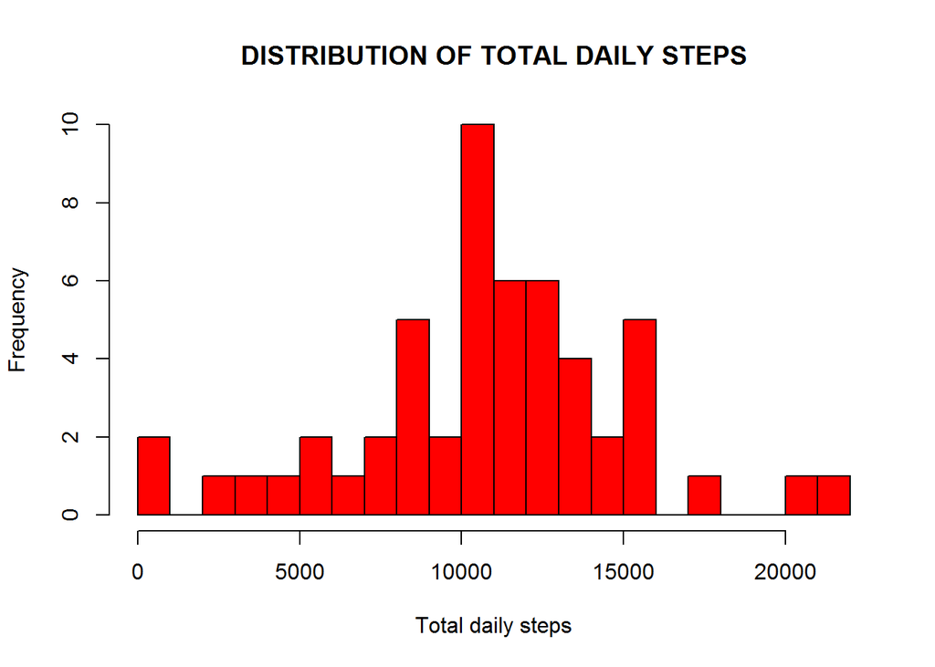

```r
hist(daily_sum,
     main = "DISTRIBUTION OF TOTAL DAILY STEPS",
     xlab = "Total daily steps",
     ylab = "Frequency",
     col = "red",
     xlim=c(0, 22000),
     ylim=c(0, 10),
     breaks=seq(0,22000,by=1000))
```

3. Calculate and report the mean and median of the total number of steps taken per day

```r
mean(daily_sum)
```

```
## [1] 10766.19
```

```r
median(daily_sum)
```

```
## [1] 10765
```

**WHAT IS THE AVERAGE DAILY ACTIVITY PATTERN?**

1. Make a time series plot of the 5-minute interval (x-axis) and the average number of steps taken, averaged across all days (y-axis)

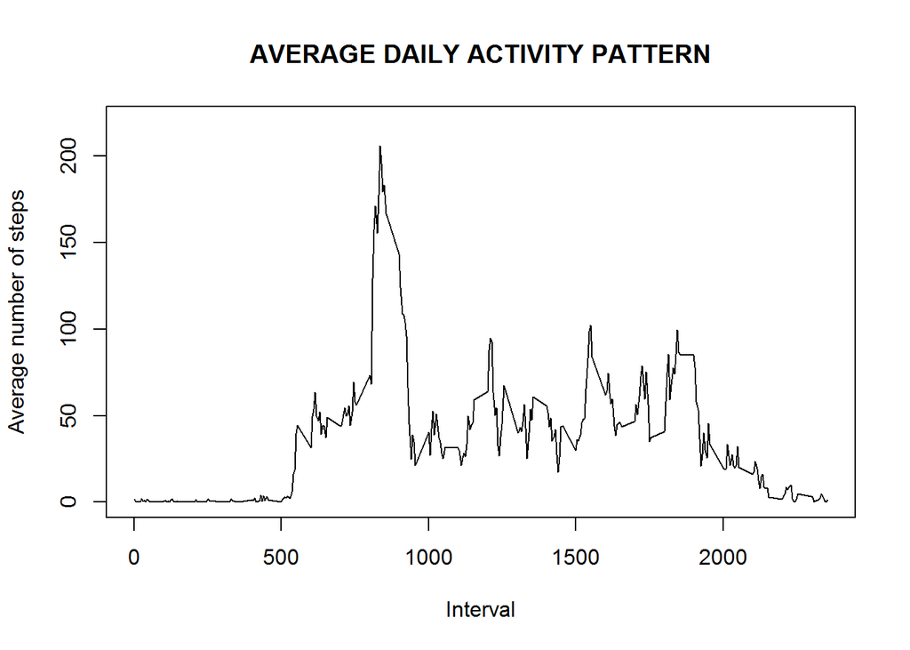

```r
int_avrg <- tapply(comp_data$steps, comp_data$interval, mean, simplify=T)
df_int_avrg <- data.frame(interval=as.integer(names(int_avrg)), average=int_avrg)
plot(df_int_avrg$interval, df_int_avrg$average,
     type = "l",
     main = "AVERAGE DAILY ACTIVITY PATTERN",
     xlab = "Interval",
     ylab = "Average number of steps",
     xlim=c(0, 2355),
     ylim=c(0, 220))
```

2. Which 5-minute interval, on average across all the days in the dataset, contains the maximum number of steps?

```r
int_max <- max(df_int_avrg$average)
subset(df_int_avrg, average == int_max)
```

```
##     interval  average
## 835      835 206.1698
```

**IMPUTING MISSING VALUES**